# Grave Analysis Project

Fortgeschrittenes Praxisprojekt - WS 25/26 LMU Munich

Arsine Chinaryan, Anh Hoang Minh Dang, Felicia Francis Immanuel, Margarita Khachatryan

Supervisor: Yichen Han

Project partners: Irene Högner, Alissa Mittnik

## Outline

**1. Project Overview**

- Overview
- Research Questions

**2. Data Description**

- Data Sets
- Process

**3. Data Visualization**

- Descriptive Plots

**4. Modelling Approach**

- Limitation
- Model Definition & Assumption
- Model Fitting (brms)

**5. Discussion**

## Outline

**1. Project Overview**

- Overview
- Research Questions

**2. Data Description**

**3. Data Visualization**

**4. Modelling Approach**

**5. Discussion**

## Project Overview

**Grave Analysis**: How do different factors influence the ratio of relatedness and unrelatedness in a collective tomb from Mycenaean times?

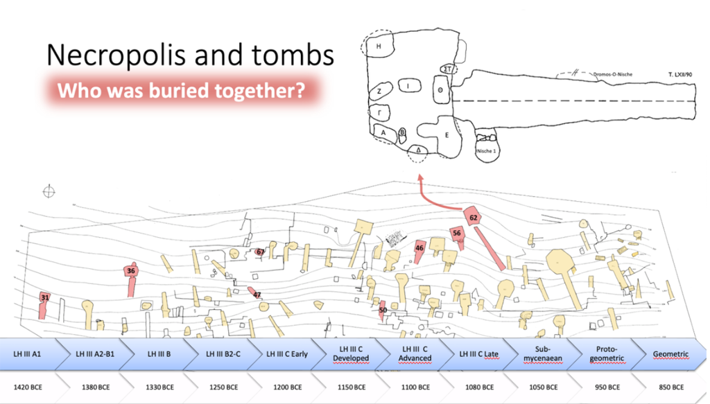

## Project Overview

- **Two burial sites**
  - Amfissa (tholos)
  - Elateia (chamber tombs): T31, T36, T46, T50, T56, T62, T67  
    **Note:** Analyze T46, T56, and T62 both as a group and as individual tombs

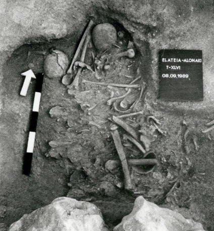

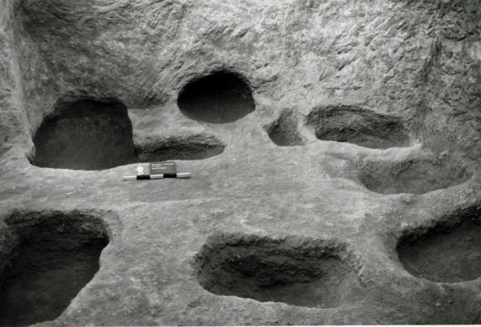

## Outline

**1. Project Overview**

**2. Data Description**

- Data Sets
- Process

**3. Data Visualization**

**4. Modelling Approach**

**5. Discussion**

## Data Description

**1. Tomb parameters** - Summary information for each tomb:

- **Minimum number of individuals (MNI)**
- **Number of analysed individuals**
- **Length of tomb use (years)**
- **Sample success rate (%)**
- Total number of samples taken per tomb
- Sampled skeletal elements:  
  petrous bone, teeth, talus/phalanx, other bones

## Data Description

**2. Individual metadata** - Information of each sampled individual:

- **Sex**
- **Age estimation**
- **Skeletal element sampled**
- **Tomb and site**
- Analysis ID
- Individual ID
- 1240k SNP coverage (indicator of DNA data quality)

## Data Description

**3. Kinship results:** Pairwise relatedness results between individuals:

- **Relationship category** (1st / 2nd / 3rd degree)
- **Kinship coefficient** (genetic measure of relatedness)
- **Overlapping SNPs** (number of shared SNPs used to estimate relatedness)
- **Low-data indicator** (indicator that OverlapNSNPs is below the reliability threshold)
- Individual pair IDs
- Upper and lower Z-scores
- Allele-sharing statistics (P0 mean, unnormalized, standard error)
- Kinship coefficient confidence intervals (min / max)
- Kinship coefficient minimum and maximum

## Research Questions

1. Develop and validate statistical models to predict the **difference between observed and potential relatedness**, using **tomb parameters** (length of use, estimated number of burials, sample success rate) as predictor variables, while accounting for potential confounding factors
2. Build predictive models to estimate **relatedness** patterns using **individual-level covariates** (sex, age and skeletal element of sample), considering that some of these factors may be confounded with DNA preservation quality and sampling success

## Outline

**1. Project Overview**

**2. Data Description**

**3. Data Visualization**

- Descriptive Plots

**4. Modelling Approach**

**5. Discussion**

## Data Visualization

### Absolute relation of MNI and analysed individuals

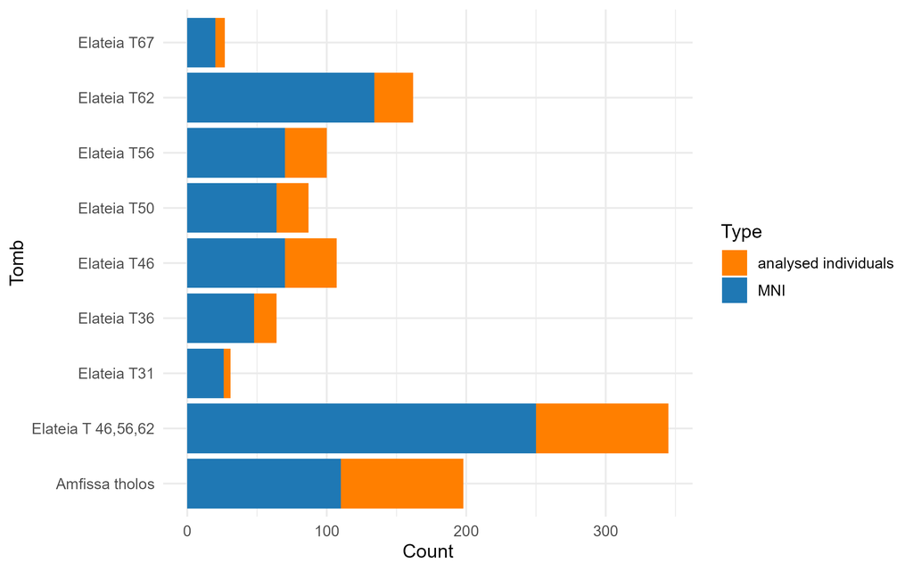

## Data Visualization

### Relative number of analysed pairs per tomb

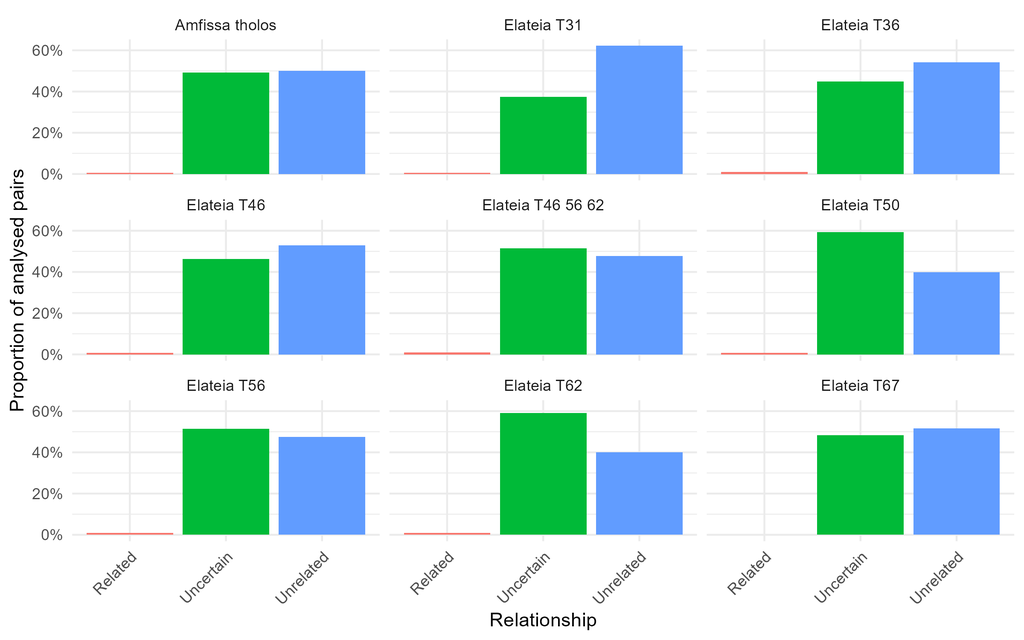

## Data Visualization

### Absolute number of analysed pairs per tomb

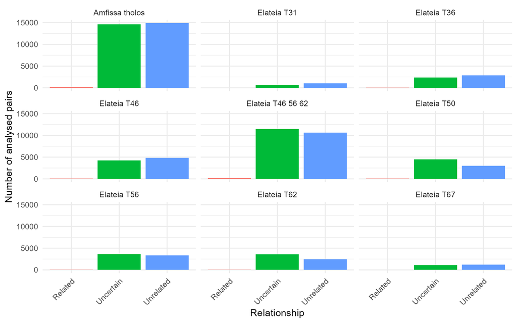

## Data Visualization

### Kinship Networks

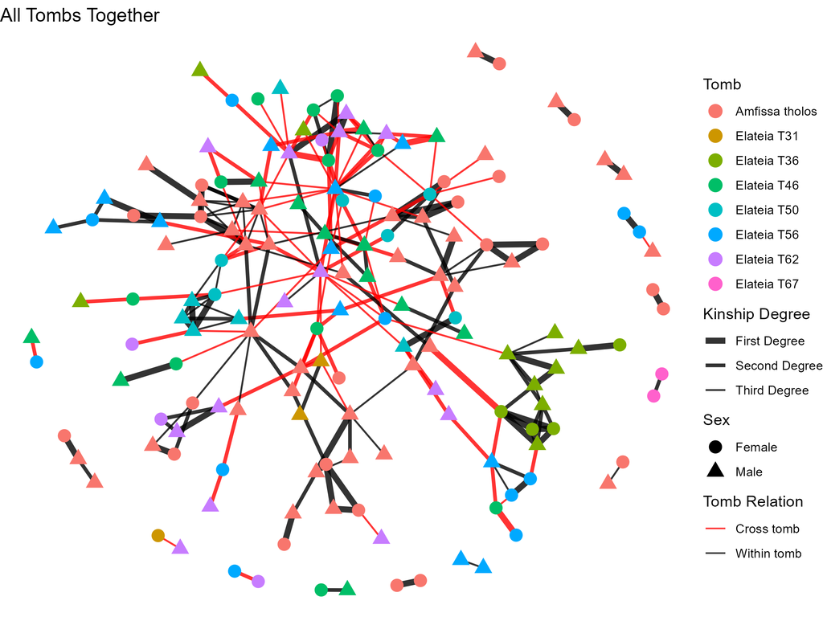

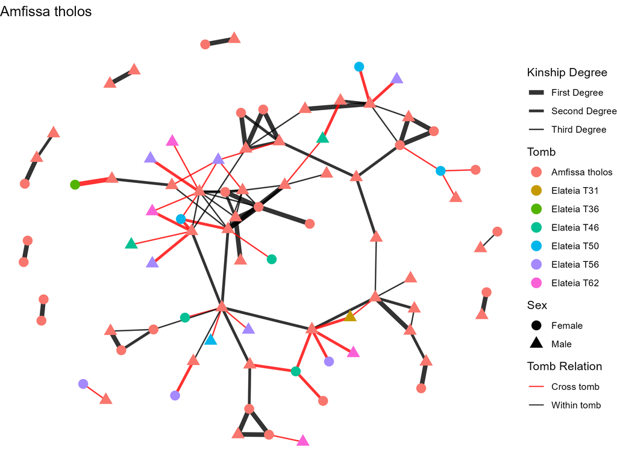

## Data Visualization

### Kinship Networks

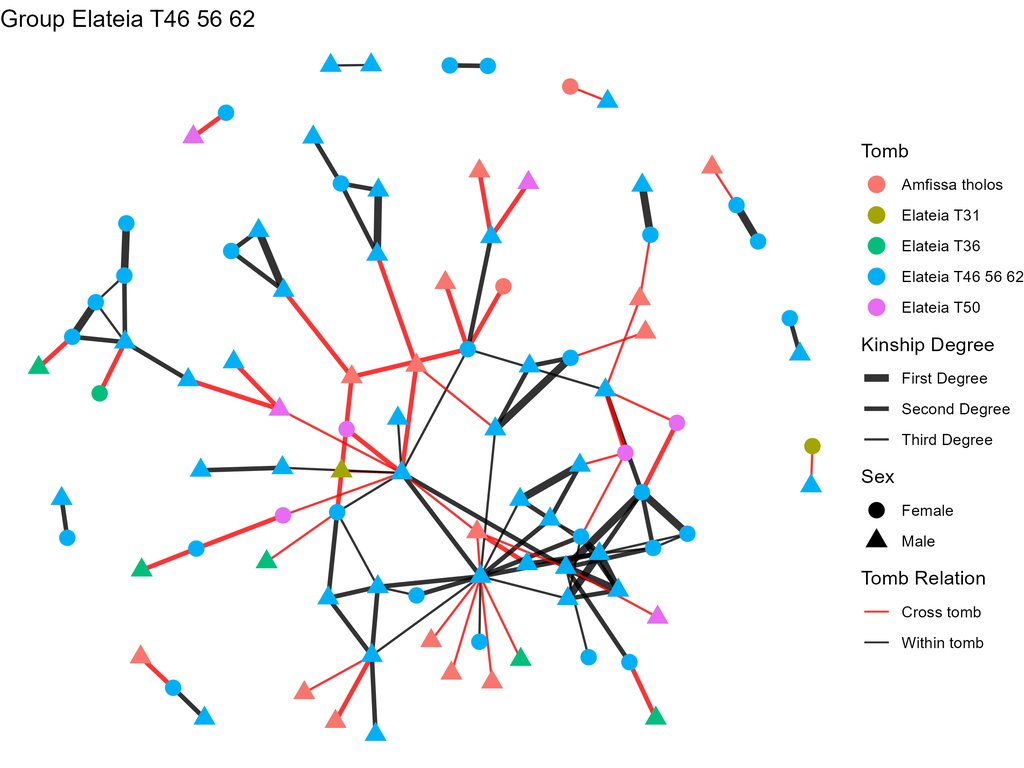

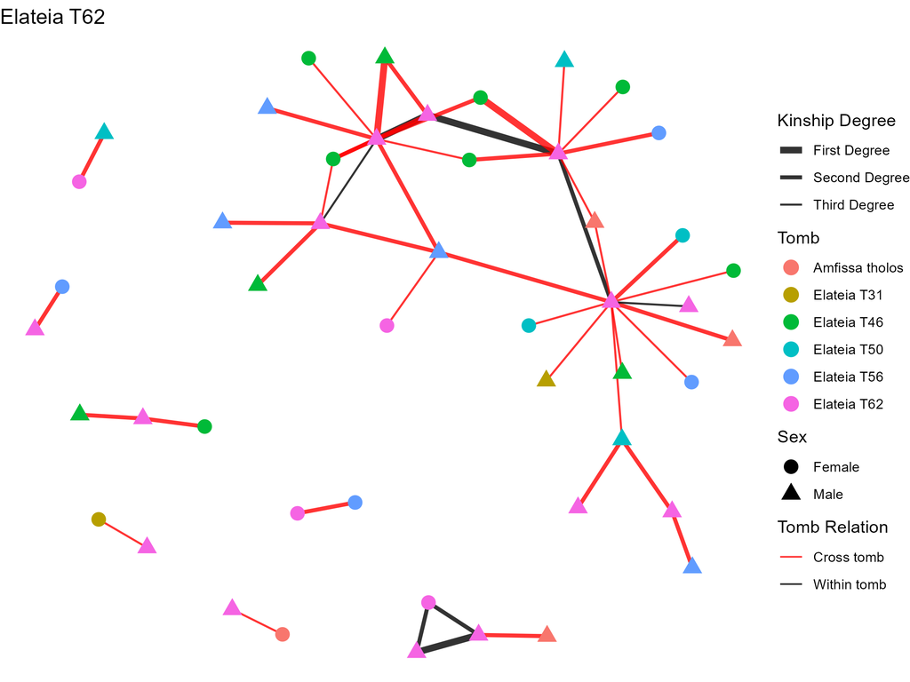

## Outline

**1. Project Overview**

**2. Data Description**

**3. Data Visualization**

**4. Modelling Approach**

- Limitation
- Model Definition And Assumption
- Fitting The Models With brms

**5. Discussion**

## Modeling Approach

### Cannot Fit a Tomb-level Model

- **Small number of tombs**: Amfissa and 7 tombs from Elateia
- For too many parameters: length of use, analysed individuals, effect of 4 types of skeletal elements

$\Rightarrow$ **With the available data, a meaningful tomb-level model is not possible**

[figure not shown]